# Practical Machine Learning Course Project

Octavio Deliberato Neto

31 de dezembro de 2018

## Executive Summary

Based on a dataset provide by PUC-Rio at http://groupware.les.inf.puc-rio.br/har, a predictive model regarding how well 6 participants were performing barbell lifting was successfully built.

Data comes from accelerometers on the belt, forearm, arm, and dumbell of 6 participants. The “classe” target variable indicates the manner in which they did the exercise.

## Getting and Preparing Data

```r
# Needed packages
library(tidyverse)
library(lessR)
library(caret)
library(FactoMineR)
library(factoextra)
library(randomForest)
library(C50)
# Is the file absent? If so, download the data
filename <- "pml-training.csv"
if (!file.exists(filename)) {
  URL <- paste0("https://d396qusza40orc.cloudfront.net/predmachlearn/",
               filename)
  download.file(URL, filename, method = "curl")
}
# load the data
mydata <- read.csv(filename, stringsAsFactors = FALSE)
```

Once the data is loaded, we need to get rid of unnecessary variables - identifiers - and others with a large amount of NAs:

```r
validcols <- colSums(is.na(mydata))/length(mydata) <= 0.05
mydata <- mydata[, validcols]
sum(colSums(is.na(mydata))) # check we are done with NAs
```

```
[1] 0
```

```r
classe <- factor(mydata$classe)
mydata <- mydata %>% select(roll_belt:classe) %>%
  select_if(is.numeric)
str(mydata)
```

```
'data.frame':   19622 obs. of  52 variables:
 $ roll_belt           : num  1.41 1.41 1.42 1.48 1.48 1.45 1.42 1.42 1.43 1.45 ...
 $ pitch_belt          : num  8.07 8.07 8.07 8.05 8.07 8.06 8.09 8.13 8.16 8.17 ...
 $ yaw_belt            : num  -94.4 -94.4 -94.4 -94.4 -94.4 -94.4 -94.4 -94.4 -94.4 -94.4 ...
 $ total_accel_belt    : int  3 3 3 3 3 3 3 3 3 3 ...
 $ gyros_belt_x        : num  0 0.02 0 0.02 0.02 0.02 0.02 0.02 0.02 0.03 ...
 $ gyros_belt_y        : num  0 0 0 0 0.02 0 0 0 0 0 ...
 $ gyros_belt_z        : num  -0.02 -0.02 -0.02 -0.03 -0.02 -0.02 -0.02 -0.02 -0.02 0 ...
 $ accel_belt_x        : int  -21 -22 -20 -22 -21 -21 -22 -22 -20 -21 ...
 $ accel_belt_y        : int  4 4 5 3 2 4 3 4 2 4 ...
 $ accel_belt_z        : int  22 22 23 21 24 21 21 21 24 22 ...
 $ magnet_belt_x       : int  -3 -7 -2 -6 -6 0 -4 -2 1 -3 ...
 $ magnet_belt_y       : int  599 608 600 604 600 603 599 603 602 609 ...
 $ magnet_belt_z       : int  -313 -311 -305 -310 -302 -312 -311 -313 -312 -308 ...
 $ roll_arm            : num  -128 -128 -128 -128 -128 -128 -128 -128 -128 -128 ...
```

[output cut: 38 more lines]

```r
mydata$classe <- classe
# ca(mydata) will generate a lot of output
```

## Dimension Reduction

As the number of variables is great, let’s try to pick the most important variables by means of PCA - Principal Component Analysis:

```r
res.pca <- PCA(subset(mydata, select = -classe), ncp = 12, graph = FALSE)
head(res.pca$eig, 12)
```

```
        eigenvalue percentage of variance
comp 1    8.356481              16.070155
comp 2    8.103312              15.583292
comp 3    4.676019               8.992345
comp 4    4.129638               7.941611
comp 5    3.651958               7.022997
comp 6    3.003560               5.776076
comp 7    2.239961               4.307617
comp 8    2.072820               3.986191
comp 9    1.717231               3.302367
comp 10   1.508821               2.901580
comp 11   1.385498               2.664419
comp 12   1.129242               2.171618
        cumulative percentage of variance
comp 1                           16.07015
comp 2                           31.65345
comp 3                           40.64579
comp 4                           48.58740
comp 5                           55.61040
comp 6                           61.38648
comp 7                           65.69409
comp 8                           69.68028
comp 9                           72.98265
comp 10                          75.88423
comp 11                          78.54865
comp 12                          80.72027
```

From the PCA we see that up to PCA12 one can represent ~80% of the total variance to be explained. Analysing each component and variable up to PCA12, the following variables were chosen:

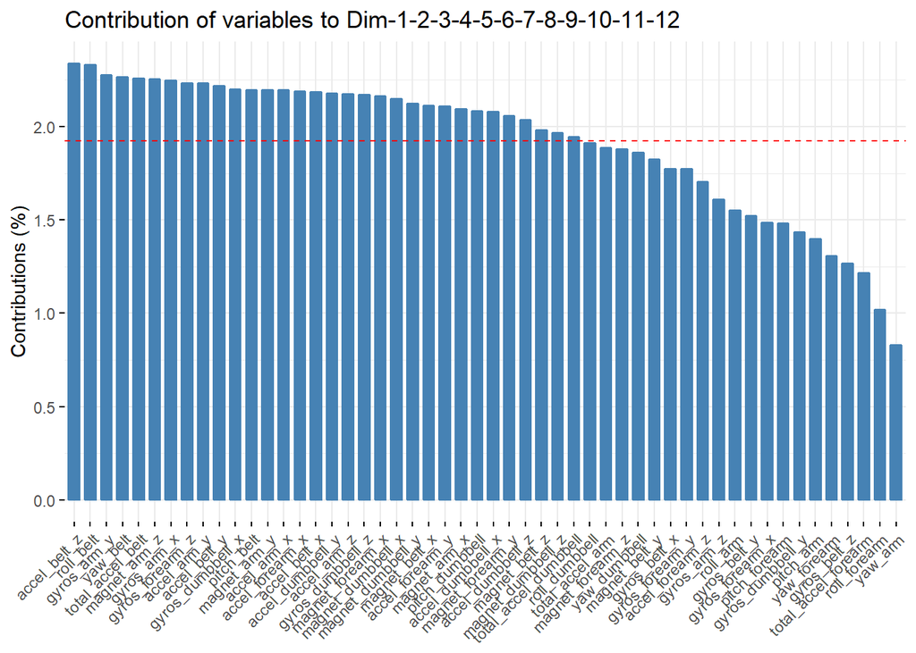

```r
fviz_contrib(res.pca, choice = "var", axes = 1:12)
```

```r
var.contribs <- c("roll_belt", "pitch_belt", "total_accel_belt",
                  "accel_belt_x", "accel_belt_y", "accel_belt_z",
                  "magnet_belt_x", "magnet_belt_z", "total_accel_arm",
                  "gyros_arm_x", "gyros_arm_y", "magnet_arm_y",
                  "roll_dumbbell", "pitch_dumbbell", "yaw_dumbbell",
                  "gyros_dumbbell_x", "gyros_dumbbell_z",
                  "gyros_forearm_y", "gyros_forearm_z",
                  "accel_forearm_y", "accel_forearm_z", "magnet_forearm_x",
                  "magnet_forearm_y", "magnet_forearm_z")
mydata <- mydata[var.contribs]
```

Finally, we can still reduce the dimensionality of the dataset further by means of eliminating highly correlated variables with the aid of `caret`:

```r
highlyCorDescr <- findCorrelation(cor(mydata), cutoff = 0.7)
mydata <- mydata[, -highlyCorDescr]
mydata$classe <- classe
names(mydata) # final set of variables
```

```
 [1] "pitch_belt"       "accel_belt_y"     "magnet_belt_z"
 [4] "total_accel_arm"  "gyros_arm_x"      "magnet_arm_y"
 [7] "roll_dumbbell"    "pitch_dumbbell"   "yaw_dumbbell"
[10] "gyros_dumbbell_x" "accel_forearm_z"  "magnet_forearm_x"
[13] "magnet_forearm_y" "magnet_forearm_z" "classe"
```

```r
summary(mydata) # final dataset
```

```
   pitch_belt        accel_belt_y    magnet_belt_z    total_accel_arm
 Min.   :-55.8000   Min.   :-69.00   Min.   :-623.0   Min.   : 1.00
 1st Qu.:  1.7600   1st Qu.:  3.00   1st Qu.:-375.0   1st Qu.:17.00
 Median :  5.2800   Median : 35.00   Median :-320.0   Median :27.00
 Mean   :  0.3053   Mean   : 30.15   Mean   :-345.5   Mean   :25.51
 3rd Qu.: 14.9000   3rd Qu.: 61.00   3rd Qu.:-306.0   3rd Qu.:33.00
 Max.   : 60.3000   Max.   :164.00   Max.   : 293.0   Max.   :66.00
  gyros_arm_x        magnet_arm_y    roll_dumbbell     pitch_dumbbell
 Min.   :-6.37000   Min.   :-392.0   Min.   :-153.71   Min.   :-149.59
 1st Qu.:-1.33000   1st Qu.:  -9.0   1st Qu.: -18.49   1st Qu.: -40.89
 Median : 0.08000   Median : 202.0   Median :  48.17   Median : -20.96
 Mean   : 0.04277   Mean   : 156.6   Mean   :  23.84   Mean   : -10.78
 3rd Qu.: 1.57000   3rd Qu.: 323.0   3rd Qu.:  67.61   3rd Qu.:  17.50
 Max.   : 4.87000   Max.   : 583.0   Max.   : 153.55   Max.   : 149.40
  yaw_dumbbell      gyros_dumbbell_x    accel_forearm_z
 Min.   :-150.871   Min.   :-204.0000   Min.   :-446.00
 1st Qu.: -77.644   1st Qu.:  -0.0300   1st Qu.:-182.00
 Median :  -3.324   Median :   0.1300   Median : -39.00
 Mean   :   1.674   Mean   :   0.1611   Mean   : -55.29
 3rd Qu.:  79.643   3rd Qu.:   0.3500   3rd Qu.:  26.00
 Max.   : 154.952   Max.   :   2.2200   Max.   : 291.00
 magnet_forearm_x  magnet_forearm_y magnet_forearm_z classe
 Min.   :-1280.0   Min.   :-896.0   Min.   :-973.0   A:5580
 1st Qu.: -616.0   1st Qu.:   2.0   1st Qu.: 191.0   B:3797
 Median : -378.0   Median : 591.0   Median : 511.0   C:3422
 Mean   : -312.6   Mean   : 380.1   Mean   : 393.6   D:3216
 3rd Qu.:  -73.0   3rd Qu.: 737.0   3rd Qu.: 653.0   E:3607
 Max.   :  672.0   Max.   :1480.0   Max.   :1090.0
```

## Model Building

### Random Forest

```r
ind.train <- createDataPartition(mydata$classe, p = 0.75, list = FALSE)
mydata.train <- mydata[ind.train, ]
mydata.test <- mydata[-ind.train, ]
set.seed(300)
rf <- randomForest(classe ~ ., mydata.train)
rf
```

```
Call:
 randomForest(formula = classe ~ ., data = mydata.train)
               Type of random forest: classification
                     Number of trees: 500
No. of variables tried at each split: 3

        OOB estimate of  error rate: 3.07%
Confusion matrix:
     A    B    C    D    E class.error
A 4049   28   33   62   13  0.03249701
B   60 2731   45    9    3  0.04108146
C   22   39 2489   17    0  0.03038566
D   25    7   61 2315    4  0.04021559
E    1    6    2   15 2682  0.00886918
```

```r
rf.pred <- predict(rf, newdata = mydata.test)
rf.acc <- confusionMatrix(rf.pred, mydata.test$classe)
# Accuracy
rf.acc$overall[[1]]
```

```
[1] 0.9683931
```

### Boosted C5.0 decision tree

```r
set.seed(300)
c5 <- C5.0(classe ~ ., data = mydata.train, trials = 30)
c5.pred <- predict(c5, newdata = mydata.test)
c5.acc <- confusionMatrix(c5.pred, mydata.test$classe)
# Accuracy
c5.acc$overall[[1]]
```

```
[1] 0.9602365
```

The Random Forest model shows slightly better accuracy than the C5.0 boosted decision tree, but both models show very good performances. Also, the approach to reducing the dimension of the dataset proved to be effective.

## Annex - Descriptive Statistics and Distributions for Selected Variables

```r
ca(mydata)
```

```
-------------------------
seg dez 31, 2018 at 14:31
-------------------------



+++++++++++++++++++++++++++++++++++++
Histogram for Each Numeric Variable
+++++++++++++++++++++++++++++++++++++
```

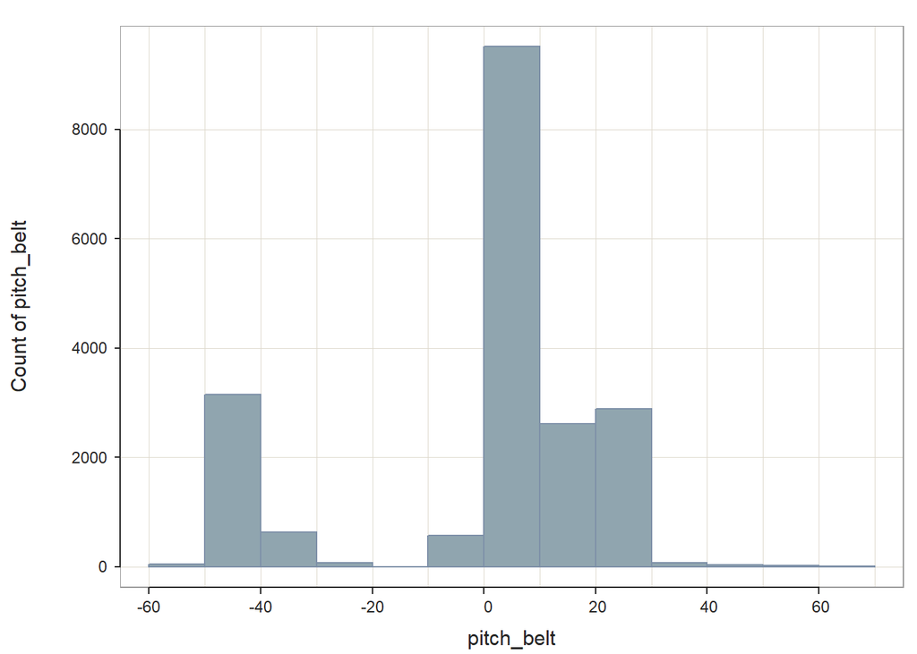

```
--- pitch_belt ---

        n   miss       mean         sd        min        mdn        max
     19622      0      0.305     22.351    -55.800      5.280     60.300


Bin Width: 10
Number of Bins: 13

       Bin  Midpnt  Count    Prop  Cumul.c  Cumul.p
---------------------------------------------------
 -60 > -50     -55     45    0.00       45     0.00
 -50 > -40     -45   3148    0.16     3193     0.16
 -40 > -30     -35    630    0.03     3823     0.19
 -30 > -20     -25     69    0.00     3892     0.20
 -20 > -10     -15      0    0.00     3892     0.20
 -10 >   0      -5    576    0.03     4468     0.23
   0 >  10       5   9514    0.48    13982     0.71
  10 >  20      15   2618    0.13    16600     0.85
  20 >  30      25   2886    0.15    19486     0.99
  30 >  40      35     70    0.00    19556     1.00
  40 >  50      45     35    0.00    19591     1.00
  50 >  60      55     25    0.00    19616     1.00
  60 >  70      65      6    0.00    19622     1.00


(Box plot) Outliers: 3984

Small        Large
-----        -----
 -55.8      60.3
 -54.9      60.3
 -54.7      60.2
 -54.4      60.1
 -53.9      60.1
 -53.9      60.1
 -53.8      60.0
 -53.5      60.0
 -53.3      60.0
 -53.2      59.9
 -53.0      59.9
 -52.1      59.9
 -52.1      59.8
 -52.1      59.8
 -52.0      59.7
 -52.0      59.4
 -52.0      59.0
 -52.0      58.8

+ 3966 more outliers
```

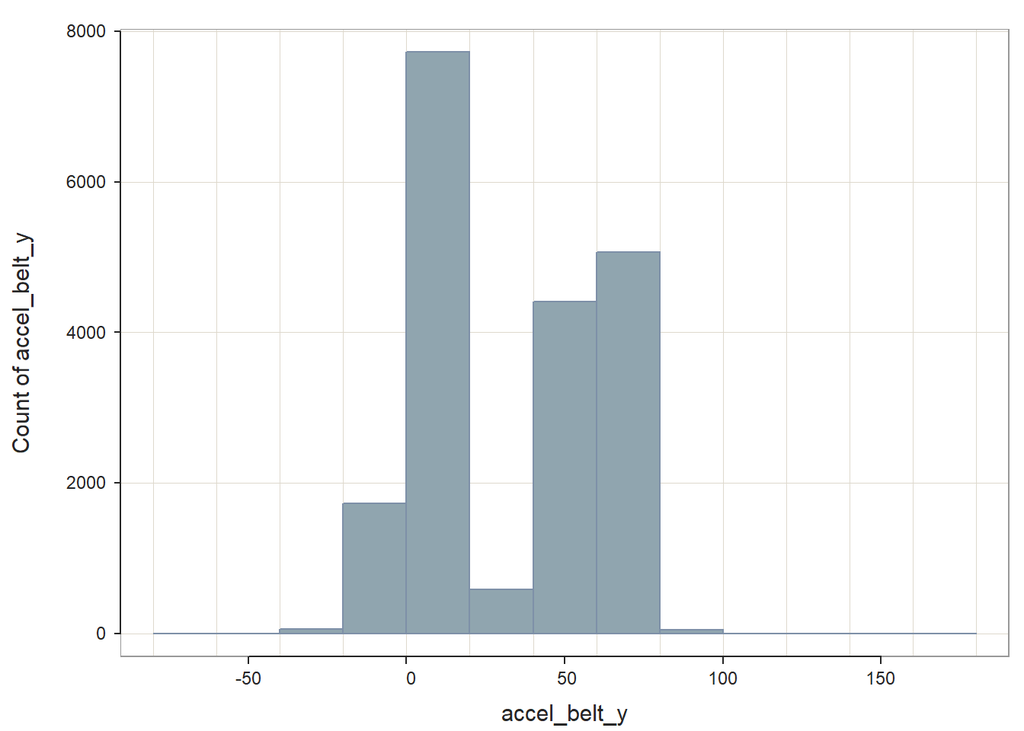

```
--- accel_belt_y ---

        n   miss     mean       sd      min      mdn      max
     19622      0    30.15    28.58   -69.00    35.00   164.00


Bin Width: 20
Number of Bins: 13

       Bin  Midpnt  Count    Prop  Cumul.c  Cumul.p
---------------------------------------------------
 -80 > -60     -70      2    0.00        2     0.00
 -60 > -40     -50      2    0.00        4     0.00
 -40 > -20     -30     63    0.00       67     0.00
 -20 >   0     -10   1728    0.09     1795     0.09
   0 >  20      10   7723    0.39     9518     0.49
  20 >  40      30    582    0.03    10100     0.51
  40 >  60      50   4407    0.22    14507     0.74
  60 >  80      70   5062    0.26    19569     1.00
  80 > 100      90     47    0.00    19616     1.00
 100 > 120     110      2    0.00    19618     1.00
 120 > 140     130      1    0.00    19619     1.00
 140 > 160     150      2    0.00    19621     1.00
 160 > 180     170      1    0.00    19622     1.00


(Box plot) Outliers: 3

Small      Large
-----      -----
            164.0
            150.0
            149.0
```

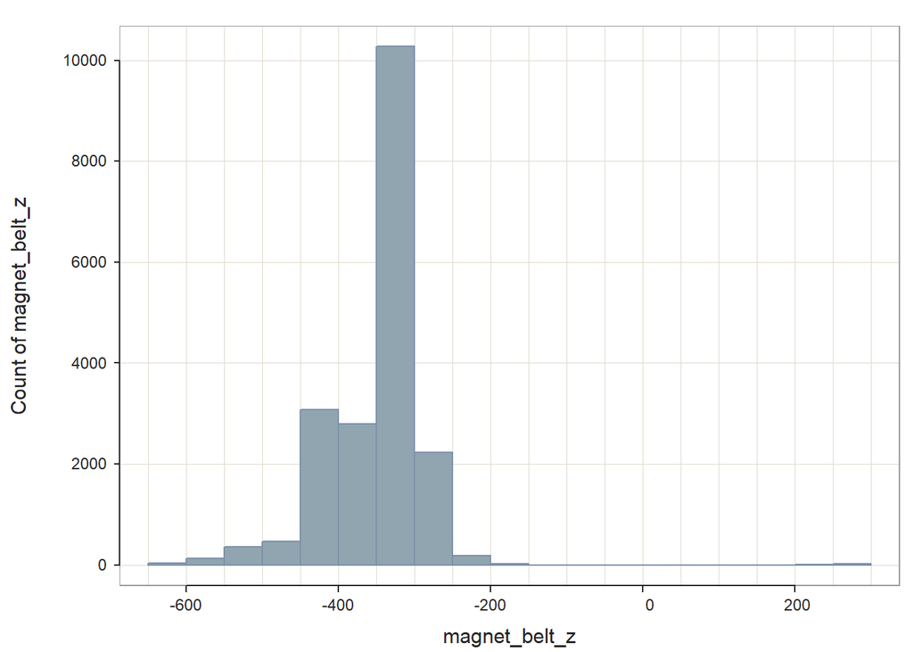

```
--- magnet_belt_z ---

        n   miss       mean         sd        min        mdn        max
     19622      0    -345.48      65.21    -623.00    -320.00     293.00


Bin Width: 50
Number of Bins: 19

         Bin  Midpnt  Count    Prop  Cumul.c  Cumul.p
-----------------------------------------------------
 -650 > -600    -625     41    0.00       41     0.00
 -600 > -550    -575    137    0.01      178     0.01
 -550 > -500    -525    361    0.02      539     0.03
 -500 > -450    -475    468    0.02     1007     0.05
 -450 > -400    -425   3075    0.16     4082     0.21
 -400 > -350    -375   2795    0.14     6877     0.35
 -350 > -300    -325  10270    0.52    17147     0.87
 -300 > -250    -275   2228    0.11    19375     0.99
 -250 > -200    -225    189    0.01    19564     1.00
 -200 > -150    -175     21    0.00    19585     1.00
 -150 > -100    -125      2    0.00    19587     1.00
 -100 >  -50     -75      0    0.00    19587     1.00
  -50 >    0     -25      1    0.00    19588     1.00
    0 >   50      25      2    0.00    19590     1.00
   50 >  100      75      2    0.00    19592     1.00
  100 >  150     125      1    0.00    19593     1.00
  150 >  200     175      3    0.00    19596     1.00
  200 >  250     225      6    0.00    19602     1.00
  250 >  300     275     20    0.00    19622     1.00


(Box plot) Outliers: 804

Small         Large
-----         -----
 -623.0       293.0
 -621.0       289.0
 -621.0       287.0
 -620.0       286.0
 -618.0       284.0
 -618.0       284.0
 -616.0       284.0
 -615.0       283.0
 -615.0       282.0
 -614.0       281.0
 -614.0       281.0
 -613.0       281.0
 -613.0       279.0
 -613.0       278.0
 -612.0       277.0
 -612.0       276.0
 -612.0       276.0
 -611.0       276.0

+ 786 more outliers
```

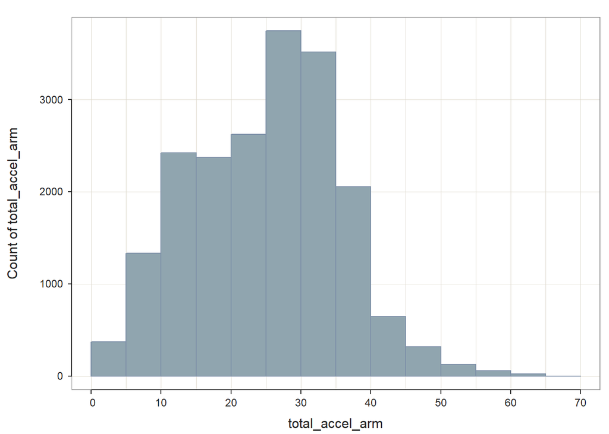

```
--- total_accel_arm ---

        n   miss     mean       sd      min      mdn      max
     19622      0    25.51    10.52     1.00    27.00    66.00


Bin Width: 5
Number of Bins: 14

     Bin  Midpnt  Count    Prop  Cumul.c  Cumul.p
-------------------------------------------------
  0 >  5     2.5    371    0.02      371     0.02
  5 > 10     7.5   1334    0.07     1705     0.09
 10 > 15    12.5   2421    0.12     4126     0.21
 15 > 20    17.5   2373    0.12     6499     0.33
 20 > 25    22.5   2626    0.13     9125     0.47
 25 > 30    27.5   3746    0.19    12871     0.66
 30 > 35    32.5   3517    0.18    16388     0.84
 35 > 40    37.5   2056    0.10    18444     0.94
 40 > 45    42.5    649    0.03    19093     0.97
 45 > 50    47.5    318    0.02    19411     0.99
 50 > 55    52.5    129    0.01    19540     1.00
 55 > 60    57.5     58    0.00    19598     1.00
 60 > 65    62.5     23    0.00    19621     1.00
 65 > 70    67.5      1    0.00    19622     1.00


(Box plot) Outliers: 58

Small      Large
-----      -----
            66.0
            65.0
            65.0
            65.0
            65.0
            64.0
            64.0
            64.0
            64.0
            64.0
            63.0
            62.0
            62.0
            62.0
            62.0
            62.0
            62.0
            62.0

+ 40 more outliers
```

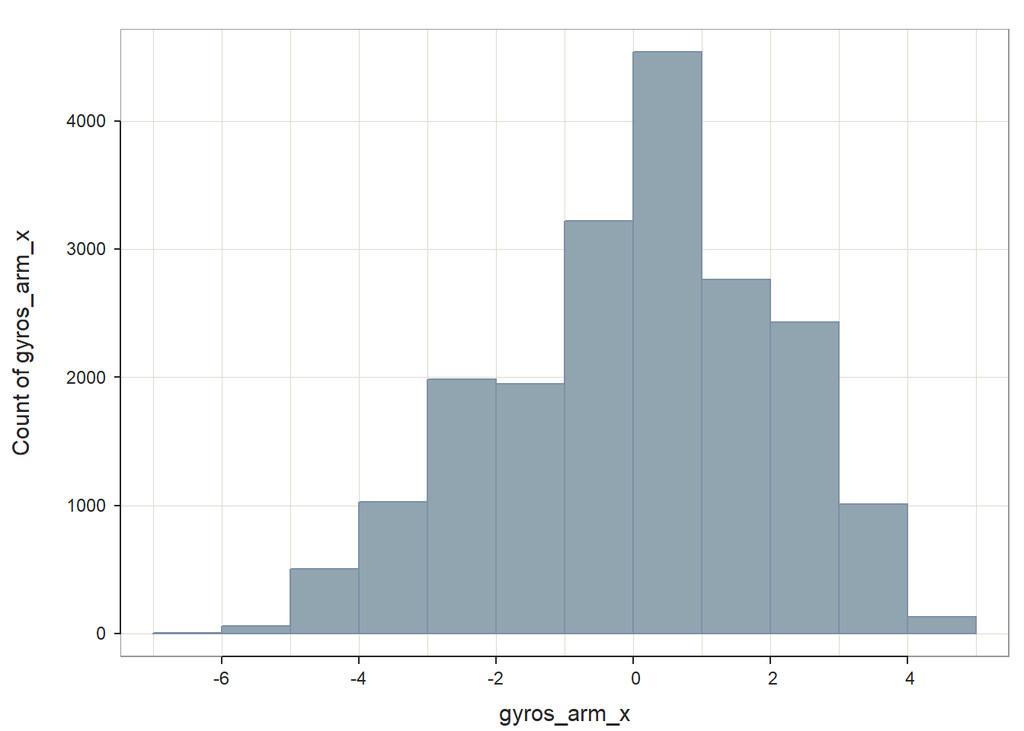

```
--- gyros_arm_x ---

        n   miss      mean        sd       min       mdn       max
     19622      0     0.043     1.994    -6.370     0.080     4.870


Bin Width: 1
Number of Bins: 12

     Bin  Midpnt  Count    Prop  Cumul.c  Cumul.p
-------------------------------------------------
 -7 > -6    -6.5      7    0.00        7     0.00
 -6 > -5    -5.5     60    0.00       67     0.00
 -5 > -4    -4.5    502    0.03      569     0.03
 -4 > -3    -3.5   1029    0.05     1598     0.08
 -3 > -2    -2.5   1987    0.10     3585     0.18
 -2 > -1    -1.5   1946    0.10     5531     0.28
 -1 >  0    -0.5   3220    0.16     8751     0.45
  0 >  1     0.5   4538    0.23    13289     0.68
  1 >  2     1.5   2765    0.14    16054     0.82
  2 >  3     2.5   2428    0.12    18482     0.94
  3 >  4     3.5   1010    0.05    19492     0.99
  4 >  5     4.5    130    0.01    19622     1.00


(Box plot) Outliers: 13

Small       Large
-----       -----
 -6.4
 -6.4
 -6.4
 -6.3
 -6.1
 -6.1
 -6.1
 -5.9
 -5.9
 -5.8
 -5.8
 -5.8
 -5.7
```

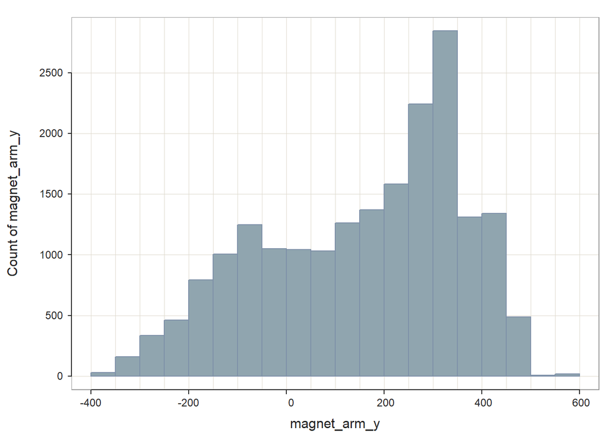

```
--- magnet_arm_y ---

        n   miss      mean        sd       min       mdn       max
     19622      0    156.61    201.91   -392.00    202.00    583.00


Bin Width: 50
Number of Bins: 20

         Bin  Midpnt  Count    Prop  Cumul.c  Cumul.p
-----------------------------------------------------
 -400 > -350    -375     29    0.00       29     0.00
 -350 > -300    -325    161    0.01      190     0.01
 -300 > -250    -275    336    0.02      526     0.03
 -250 > -200    -225    462    0.02      988     0.05
 -200 > -150    -175    793    0.04     1781     0.09
 -150 > -100    -125   1004    0.05     2785     0.14
 -100 >  -50     -75   1246    0.06     4031     0.21
  -50 >    0     -25   1051    0.05     5082     0.26
    0 >   50      25   1043    0.05     6125     0.31
   50 >  100      75   1032    0.05     7157     0.36
  100 >  150     125   1264    0.06     8421     0.43
  150 >  200     175   1369    0.07     9790     0.50
  200 >  250     225   1584    0.08    11374     0.58
  250 >  300     275   2243    0.11    13617     0.69
  300 >  350     325   2844    0.14    16461     0.84
  350 >  400     375   1310    0.07    17771     0.91
  400 >  450     425   1340    0.07    19111     0.97
  450 >  500     475    487    0.02    19598     1.00
  500 >  550     525      5    0.00    19603     1.00
  550 >  600     575     19    0.00    19622     1.00


No (Box plot) outliers
```

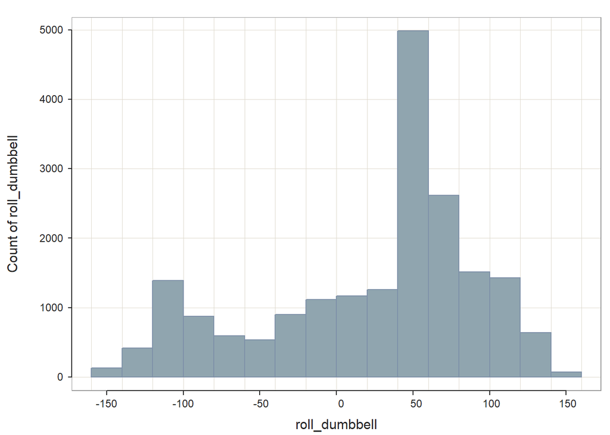

```
--- roll_dumbbell ---

        n   miss                mean                  sd                 min                 mdn                 max
     19622      0         23.84151248         69.93172026       -153.71372920         48.17424053        153.54557080


Bin Width: 20
Number of Bins: 16

         Bin  Midpnt  Count    Prop  Cumul.c  Cumul.p
-----------------------------------------------------
 -160 > -140    -150    128    0.01      128     0.01
 -140 > -120    -130    417    0.02      545     0.03
 -120 > -100    -110   1390    0.07     1935     0.10
 -100 >  -80     -90    871    0.04     2806     0.14
  -80 >  -60     -70    593    0.03     3399     0.17
  -60 >  -40     -50    533    0.03     3932     0.20
  -40 >  -20     -30    899    0.05     4831     0.25
  -20 >    0     -10   1112    0.06     5943     0.30
    0 >   20      10   1165    0.06     7108     0.36
   20 >   40      30   1258    0.06     8366     0.43
   40 >   60      50   4983    0.25    13349     0.68
   60 >   80      70   2619    0.13    15968     0.81
   80 >  100      90   1514    0.08    17482     0.89
  100 >  120     110   1430    0.07    18912     0.96
  120 >  140     130    640    0.03    19552     1.00
  140 >  160     150     70    0.00    19622     1.00


(Box plot) Outliers: 28

Small         Large
-----         -----
 -153.7
 -153.5
 -152.8
 -152.4
 -152.0
 -152.0
 -152.0
 -151.8
 -151.6
 -151.5
 -150.9
 -150.9
 -150.4
 -150.4
 -150.2
 -149.8
 -149.8
 -149.7

+ 10 more outliers
```

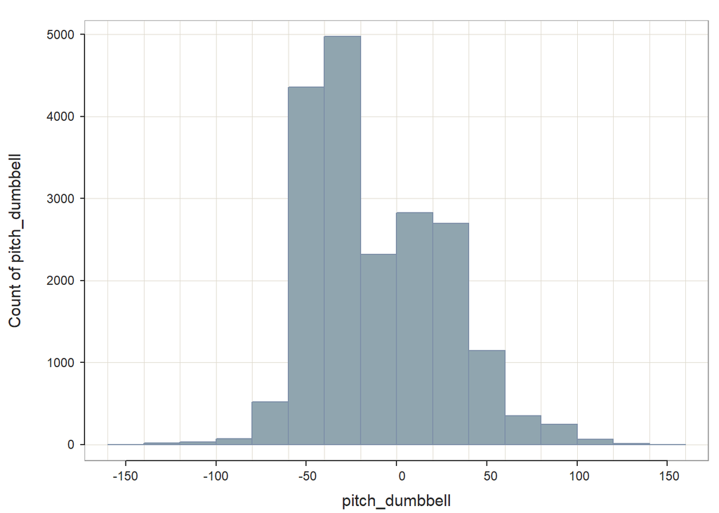

```
--- pitch_dumbbell ---

        n   miss                 mean                   sd                  min                  mdn                  max
     19622      0         -10.77941961          36.99351348        -149.59364790         -20.95772136         149.40244360


Bin Width: 20
Number of Bins: 16

         Bin  Midpnt  Count    Prop  Cumul.c  Cumul.p
-----------------------------------------------------
 -160 > -140    -150      2    0.00        2     0.00
 -140 > -120    -130     19    0.00       21     0.00
 -120 > -100    -110     30    0.00       51     0.00
 -100 >  -80     -90     70    0.00      121     0.01
  -80 >  -60     -70    518    0.03      639     0.03
  -60 >  -40     -50   4358    0.22     4997     0.25
  -40 >  -20     -30   4974    0.25     9971     0.51
  -20 >    0     -10   2317    0.12    12288     0.63
    0 >   20      10   2827    0.14    15115     0.77
   20 >   40      30   2694    0.14    17809     0.91
   40 >   60      50   1146    0.06    18955     0.97
   60 >   80      70    348    0.02    19303     0.98
   80 >  100      90    245    0.01    19548     1.00
  100 >  120     110     63    0.00    19611     1.00
  120 >  140     130     10    0.00    19621     1.00
  140 >  160     150      1    0.00    19622     1.00


(Box plot) Outliers: 46

Small         Large
-----         -----
 -149.6      149.4
 -148.5      137.0
 -137.3      129.8
 -134.7      129.5
 -130.1      127.9
 -130.0      126.8
 -130.0      126.5
 -130.0      122.5
 -130.0      121.4
 -130.0      121.4
 -130.0      121.2
 -130.0      119.0
 -129.9      117.6
 -129.9      115.0
 -129.5      114.6
 -129.5      112.3
             111.2
             111.1

+ 28 more outliers
```

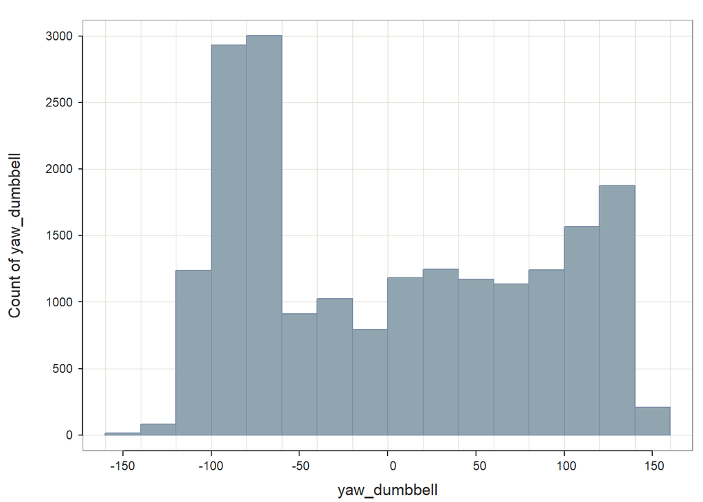

```
--- yaw_dumbbell ---

        n   miss                mean                  sd                 min                 mdn                 max
     19622      0          1.67436073         82.51719167       -150.87115420         -3.32377020        154.95229410


Bin Width: 20
Number of Bins: 16

         Bin  Midpnt  Count    Prop  Cumul.c  Cumul.p
-----------------------------------------------------
 -160 > -140    -150     14    0.00       14     0.00
 -140 > -120    -130     81    0.00       95     0.00
 -120 > -100    -110   1239    0.06     1334     0.07
 -100 >  -80     -90   2932    0.15     4266     0.22
  -80 >  -60     -70   3001    0.15     7267     0.37
  -60 >  -40     -50    913    0.05     8180     0.42
  -40 >  -20     -30   1024    0.05     9204     0.47
  -20 >    0     -10    794    0.04     9998     0.51
    0 >   20      10   1183    0.06    11181     0.57
   20 >   40      30   1246    0.06    12427     0.63
   40 >   60      50   1172    0.06    13599     0.69
   60 >   80      70   1134    0.06    14733     0.75
   80 >  100      90   1243    0.06    15976     0.81
  100 >  120     110   1566    0.08    17542     0.89
  120 >  140     130   1873    0.10    19415     0.99
  140 >  160     150    207    0.01    19622     1.00


No (Box plot) outliers
```

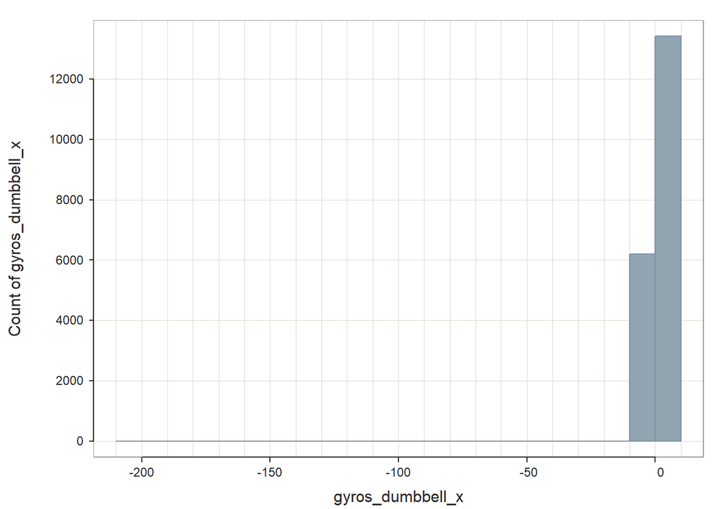

```
--- gyros_dumbbell_x ---

        n   miss      mean        sd       min       mdn       max
     19622      0     0.161     1.509  -204.000     0.130     2.220


Bin Width: 10
Number of Bins: 22

         Bin  Midpnt  Count    Prop  Cumul.c  Cumul.p
-----------------------------------------------------
 -210 > -200    -205      1    0.00        1     0.00
 -200 > -190    -195      0    0.00        1     0.00
 -190 > -180    -185      0    0.00        1     0.00
 -180 > -170    -175      0    0.00        1     0.00
 -170 > -160    -165      0    0.00        1     0.00
 -160 > -150    -155      0    0.00        1     0.00
 -150 > -140    -145      0    0.00        1     0.00
 -140 > -130    -135      0    0.00        1     0.00
 -130 > -120    -125      0    0.00        1     0.00
 -120 > -110    -115      0    0.00        1     0.00
 -110 > -100    -105      0    0.00        1     0.00
 -100 >  -90     -95      0    0.00        1     0.00
  -90 >  -80     -85      0    0.00        1     0.00
  -80 >  -70     -75      0    0.00        1     0.00
  -70 >  -60     -65      0    0.00        1     0.00
  -60 >  -50     -55      0    0.00        1     0.00
  -50 >  -40     -45      0    0.00        1     0.00
  -40 >  -30     -35      0    0.00        1     0.00
  -30 >  -20     -25      0    0.00        1     0.00
  -20 >  -10     -15      0    0.00        1     0.00
  -10 >    0      -5   6206    0.32     6207     0.32
    0 >   10       5  13415    0.68    19622     1.00


(Box plot) Outliers: 1223

Small         Large
-----         -----
 -204.0      2.2
   -2.0      2.2
   -2.0      2.2
   -1.9      2.1
   -1.9      2.1
   -1.8      2.1
   -1.8      2.0
   -1.8      2.0
   -1.8      2.0
   -1.8      1.9
   -1.8      1.9
   -1.8      1.9
   -1.8      1.9
   -1.8      1.9
   -1.8      1.9
   -1.8      1.9
   -1.8      1.9
   -1.7      1.9

+ 1205 more outliers
```

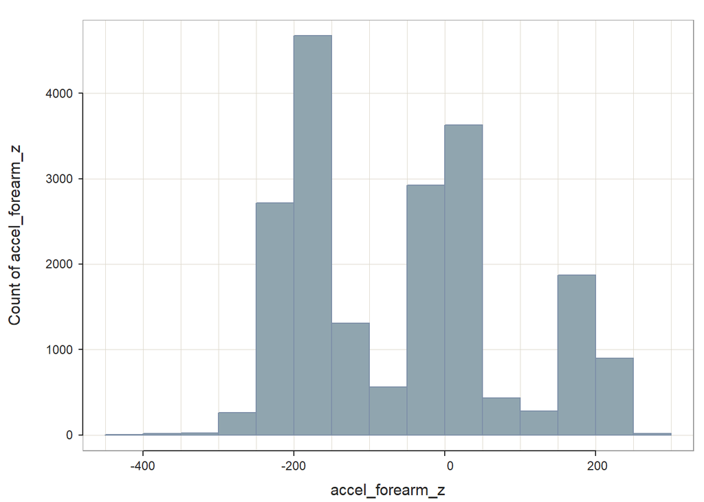

```
--- accel_forearm_z ---

        n   miss      mean        sd       min       mdn       max
     19622      0    -55.29    138.40   -446.00    -39.00    291.00


Bin Width: 50
Number of Bins: 15

         Bin  Midpnt  Count    Prop  Cumul.c  Cumul.p
-----------------------------------------------------
 -450 > -400    -425      2    0.00        2     0.00
 -400 > -350    -375     15    0.00       17     0.00
 -350 > -300    -325     24    0.00       41     0.00
 -300 > -250    -275    263    0.01      304     0.02
 -250 > -200    -225   2717    0.14     3021     0.15
 -200 > -150    -175   4673    0.24     7694     0.39
 -150 > -100    -125   1306    0.07     9000     0.46
 -100 >  -50     -75    565    0.03     9565     0.49
  -50 >    0     -25   2925    0.15    12490     0.64
    0 >   50      25   3626    0.18    16116     0.82
   50 >  100      75    435    0.02    16551     0.84
  100 >  150     125    283    0.01    16834     0.86
  150 >  200     175   1872    0.10    18706     0.95
  200 >  250     225    901    0.05    19607     1.00
  250 >  300     275     15    0.00    19622     1.00


No (Box plot) outliers
```

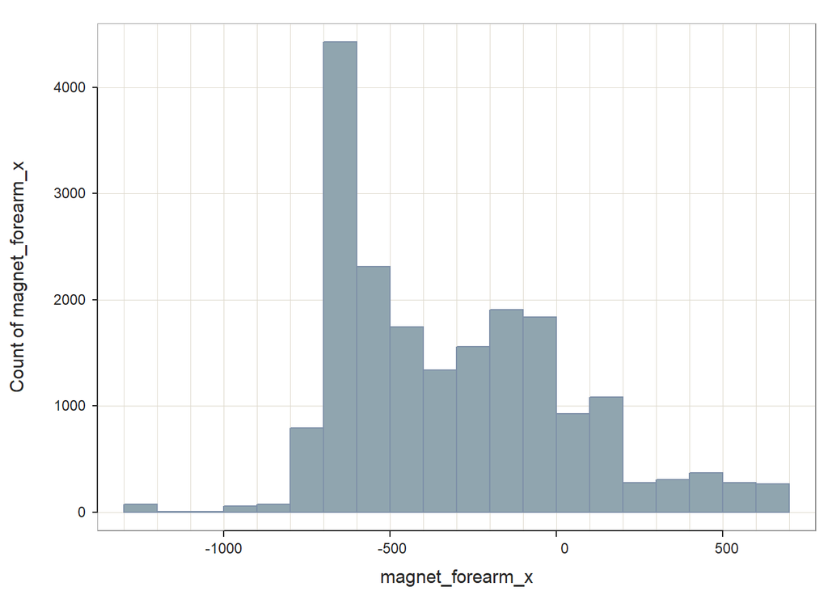

```
--- magnet_forearm_x ---

        n   miss       mean         sd        min        mdn        max
     19622      0    -312.58     346.96   -1280.00    -378.00     672.00


Bin Width: 100
Number of Bins: 20

           Bin  Midpnt  Count    Prop  Cumul.c  Cumul.p
-------------------------------------------------------
 -1300 > -1200   -1250     73    0.00       73     0.00
 -1200 > -1100   -1150      7    0.00       80     0.00
 -1100 > -1000   -1050      6    0.00       86     0.00
 -1000 >  -900    -950     57    0.00      143     0.01
  -900 >  -800    -850     74    0.00      217     0.01
  -800 >  -700    -750    795    0.04     1012     0.05
  -700 >  -600    -650   4424    0.23     5436     0.28
  -600 >  -500    -550   2309    0.12     7745     0.39
  -500 >  -400    -450   1745    0.09     9490     0.48
  -400 >  -300    -350   1338    0.07    10828     0.55
  -300 >  -200    -250   1555    0.08    12383     0.63
  -200 >  -100    -150   1903    0.10    14286     0.73
  -100 >     0     -50   1837    0.09    16123     0.82
     0 >   100      50    926    0.05    17049     0.87
   100 >   200     150   1082    0.06    18131     0.92
   200 >   300     250    275    0.01    18406     0.94
   300 >   400     350    305    0.02    18711     0.95
   400 >   500     450    370    0.02    19081     0.97
   500 >   600     550    276    0.01    19357     0.99
   600 >   700     650    265    0.01    19622     1.00


No (Box plot) outliers
```

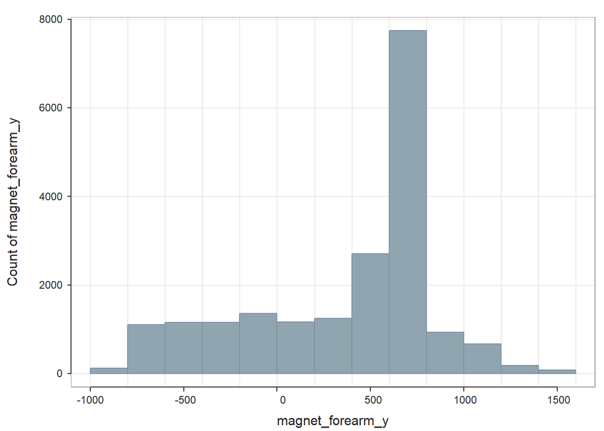

```
--- magnet_forearm_y ---

        n   miss         mean           sd          min          mdn          max
     19622      0     380.1164     509.3737    -896.0000     591.0000    1480.0000


Bin Width: 200
Number of Bins: 13

           Bin  Midpnt  Count    Prop  Cumul.c  Cumul.p
-------------------------------------------------------
 -1000 >  -800    -900    121    0.01      121     0.01
  -800 >  -600    -700   1101    0.06     1222     0.06
  -600 >  -400    -500   1153    0.06     2375     0.12
  -400 >  -200    -300   1158    0.06     3533     0.18
  -200 >     0    -100   1360    0.07     4893     0.25
     0 >   200     100   1167    0.06     6060     0.31
   200 >   400     300   1246    0.06     7306     0.37
   400 >   600     500   2708    0.14    10014     0.51
   600 >   800     700   7740    0.39    17754     0.90
   800 >  1000     900    931    0.05    18685     0.95
  1000 >  1200    1100    669    0.03    19354     0.99
  1200 >  1400    1300    185    0.01    19539     1.00
  1400 >  1600    1500     83    0.00    19622     1.00


No (Box plot) outliers
```

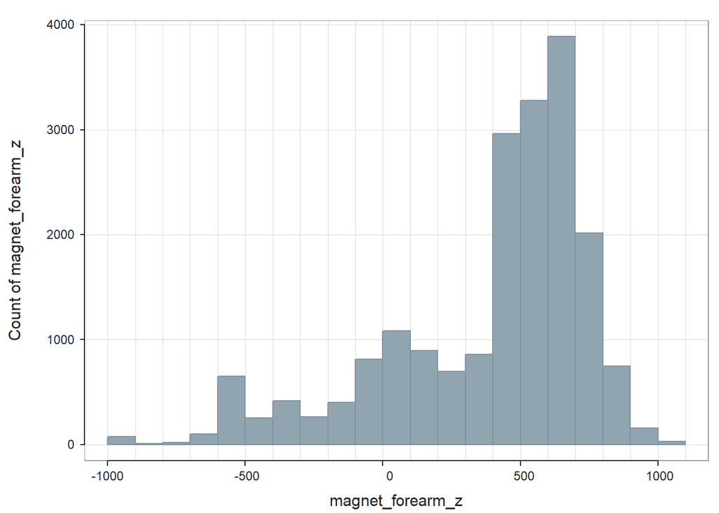

```
--- magnet_forearm_z ---

        n   miss           mean             sd            min            mdn            max
     19622      0      393.61375      369.26875     -973.00000      511.00000     1090.00000


Bin Width: 100
Number of Bins: 21

           Bin  Midpnt  Count    Prop  Cumul.c  Cumul.p
-------------------------------------------------------
 -1000 >  -900    -950     76    0.00       76     0.00
  -900 >  -800    -850      9    0.00       85     0.00
  -800 >  -700    -750     17    0.00      102     0.01
  -700 >  -600    -650    100    0.01      202     0.01
  -600 >  -500    -550    652    0.03      854     0.04
  -500 >  -400    -450    254    0.01     1108     0.06
  -400 >  -300    -350    419    0.02     1527     0.08
  -300 >  -200    -250    263    0.01     1790     0.09
  -200 >  -100    -150    402    0.02     2192     0.11
  -100 >     0     -50    816    0.04     3008     0.15
     0 >   100      50   1084    0.06     4092     0.21
   100 >   200     150    894    0.05     4986     0.25
   200 >   300     250    697    0.04     5683     0.29
   300 >   400     350    862    0.04     6545     0.33
   400 >   500     450   2963    0.15     9508     0.48
   500 >   600     550   3276    0.17    12784     0.65
   600 >   700     650   3887    0.20    16671     0.85
   700 >   800     750   2014    0.10    18685     0.95
   800 >   900     850    749    0.04    19434     0.99
   900 >  1000     950    159    0.01    19593     1.00
  1000 >  1100    1050     29    0.00    19622     1.00


(Box plot) Outliers: 839

Small         Large
-----         -----
 -973.0
 -966.0
```

[output cut: 10 more lines]

```
 -960.0
 -960.0
 -960.0
 -960.0
 -960.0
 -960.0

+ 821 more outliers




+++++++++++++++++++++++++++++++++++++++
Bar Chart for Each Non-numeric Variable
+++++++++++++++++++++++++++++++++++++++
```

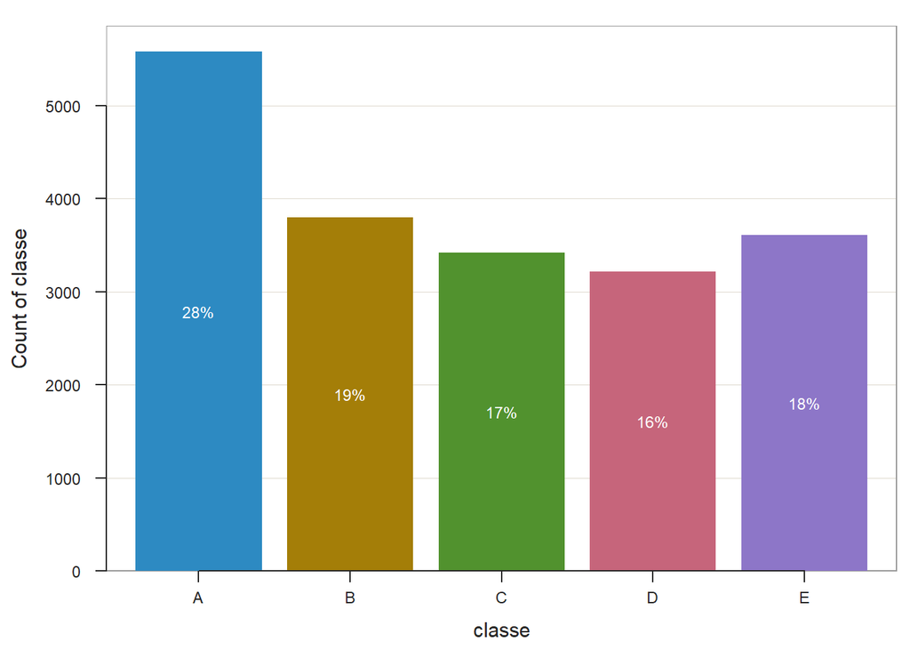

```
--- classe ---


Missing Values of classe: 0

                   A      B      C      D      E       Total
Frequencies:    5580   3797   3422   3216   3607       19622
Proportions:   0.284  0.194  0.174  0.164  0.184       1.000


Chi-squared test of null hypothesis of equal probabilities
  Chisq = 920.452, df = 4, p-value = 0.000
```